# Proyecto final

Marvin Munoz Zamora

30 de noviembre de 2020

# Proyecto Final!

### Â¿Cual es la pregunta especifica de la investigacion?

La pregunta corresponde a cual seria el efecto del area de un zona o sitio y la disponibilidad de vegetaciÃ³n en la riqueza de especies de aves en parques urbanos ubicados en Costa Ria.

Los datos fueron recolectados por 6 personas, Gabriel Ugarte, Camila valverde, Bernadeth Cubillo, Jason Martinez, Tatiana Rodriguez y mi persona

### Â¿Cuales son la variables relevantes y cual es su relacion, conocida y/o hipotetica?

Entre las variables presentes en la investigación, tenemos el area en m2 de los diversos parques para el muestreo, de forma que entre mas grandes sean, mayor riqueza de aves va a haber, mientras que si son pequeño, la riqueza de aves va a hacer minima. Otra de las variables, es el número de árboles, que sigue un mismo camino, entre más hay, mayor numero de especies de aves, pero dentro de este tambien entran dos variables, lo que corresponde a su tamaño, clasificando arboles grandes y pequeños difereciandolos por el metro 3, los mismo con el número de arbustos y palmeras, misma dinamica, dos variables y diferencia de tamaños. En estas últimas variables la presencia de mas arboles grandes o altos determinaba mayor riqueza, esperando lo contrario con los arboles pequeños.

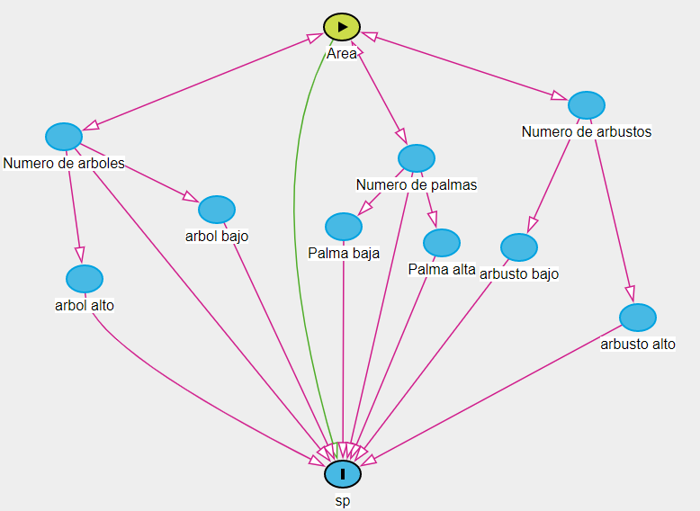

### ¿De dónde vienen los datos? Si son datos empíricos debe incluir el código para su procesamiento desde datos crudos, hasta datos analizables. Si son datos simulados debe incluir el código de simulación

Los datos vienen de la recolecta de datos durante dos dias, exactamente el 1 y 2 de noviembre de 2019, se tomaron desde las 6:00 am hasta las 8:20 am, de los cuales se hicieron puntos de muestreo de 20 minutos, para avistar las aves, con un radio de vision de 15 a 20 metros, cada punto se separo por 15 m.

Se tomaron en 6 parques diferentes, ubicados en diferentes zonas, principalmente en San Jose, el Parque de Sabanilla (9°56’44.5“N 84°02’02.7”W), el Parque Itskazu (9°56’06.5“N 84°08’06.0”W), el Parque de Granadilla (9°56’12.1“N 84°00’58.4”W) y el Parque de Pinares, el Parque Central de Santo Domingo de Heredia en la provincia de Heredia (9°58’47.8“N 84°05’27.7”W) y el Parque de Lomas de Altamira de la Guácima en la provincia de Alajuela (9°57’52.2“N 84°15’24.4”W).

Codigo de procesamiento

```r
#En primer lugar la activacion de los Packages a utilizar

library(tidyverse)
```

```r
library(ggplot2)
library(dplyr)
library(tidyr)
library(readr)

# Abrir los datos y ver su contenido

setwd('C:/Users/Est3ban/Desktop/Proyecto')

modelo_final <- read_csv("modelo_final.csv")
modelo_final
```

```
## # A tibble: 6 x 13
##      ID Parque    sp area_m2 arbol_alto arbol_peq arbusto_alt arbusto_peq
##   <dbl> <chr>  <dbl>   <dbl>      <dbl>     <dbl>       <dbl>       <dbl>
## 1     1 Santo~    10   8187.         85         7           1           1
## 2     2 Grana~     9   6337.         40         3           5          16
## 3     3 Guaci~     4   2003.         17         7           0           0
## 4     4 Pinar~    15  13434.         76        79          21          31
## 5     5 Saban~     7   3218.          9        20           2          10
## 6     6 Itska~     8   5048           6         5           1           2
## # ... with 5 more variables: palma_alt <dbl>, palma_peq <dbl>,
## #   numero_arboles <dbl>, numero_arbustos <dbl>, numero_palma <dbl>
```

```r
glimpse(modelo_final)
```

```
## Rows: 6
## Columns: 13
## $ ID              <dbl> 1, 2, 3, 4, 5, 6
## $ Parque          <chr> "Santo Domingo", "Granadilla", "Guacima", "Pin...
## $ sp              <dbl> 10, 9, 4, 15, 7, 8
## $ area_m2         <dbl> 8187.43, 6336.56, 2002.61, 13434.38, 3218.18, ...
## $ arbol_alto      <dbl> 85, 40, 17, 76, 9, 6
## $ arbol_peq       <dbl> 7, 3, 7, 79, 20, 5
## $ arbusto_alt     <dbl> 1, 5, 0, 21, 2, 1
## $ arbusto_peq     <dbl> 1, 16, 0, 31, 10, 2
## $ palma_alt       <dbl> 28, 0, 9, 11, 0, 1
## $ palma_peq       <dbl> 0, 0, 0, 0, 0, 8
## $ numero_arboles  <dbl> 92, 43, 24, 155, 29, 11
## $ numero_arbustos <dbl> 2, 21, 0, 52, 12, 3
## $ numero_palma    <dbl> 28, 0, 9, 11, 0, 9
```

```r
summary(modelo_final)
```

```
##        ID          Parque                sp            area_m2
##  Min.   :1.00   Length:6           Min.   : 4.000   Min.   : 2003
##  1st Qu.:2.25   Class :character   1st Qu.: 7.250   1st Qu.: 3676
##  Median :3.50   Mode  :character   Median : 8.500   Median : 5692
##  Mean   :3.50                      Mean   : 8.833   Mean   : 6371
##  3rd Qu.:4.75                      3rd Qu.: 9.750   3rd Qu.: 7725
##  Max.   :6.00                      Max.   :15.000   Max.   :13434
##    arbol_alto      arbol_peq      arbusto_alt     arbusto_peq
##  Min.   : 6.00   Min.   : 3.00   Min.   : 0.00   Min.   : 0.00
##  1st Qu.:11.00   1st Qu.: 5.50   1st Qu.: 1.00   1st Qu.: 1.25
##  Median :28.50   Median : 7.00   Median : 1.50   Median : 6.00
##  Mean   :38.83   Mean   :20.17   Mean   : 5.00   Mean   :10.00
##  3rd Qu.:67.00   3rd Qu.:16.75   3rd Qu.: 4.25   3rd Qu.:14.50
##  Max.   :85.00   Max.   :79.00   Max.   :21.00   Max.   :31.00
##    palma_alt        palma_peq     numero_arboles   numero_arbustos
##  Min.   : 0.000   Min.   :0.000   Min.   : 11.00   Min.   : 0.00
##  1st Qu.: 0.250   1st Qu.:0.000   1st Qu.: 25.25   1st Qu.: 2.25
##  Median : 5.000   Median :0.000   Median : 36.00   Median : 7.50
##  Mean   : 8.167   Mean   :1.333   Mean   : 59.00   Mean   :15.00
##  3rd Qu.:10.500   3rd Qu.:0.000   3rd Qu.: 79.75   3rd Qu.:18.75
##  Max.   :28.000   Max.   :8.000   Max.   :155.00   Max.   :52.00
##   numero_palma
##  Min.   : 0.00
##  1st Qu.: 2.25
##  Median : 9.00
##  Mean   : 9.50
##  3rd Qu.:10.50
##  Max.   :28.00
```

```r
View(modelo_final)
```

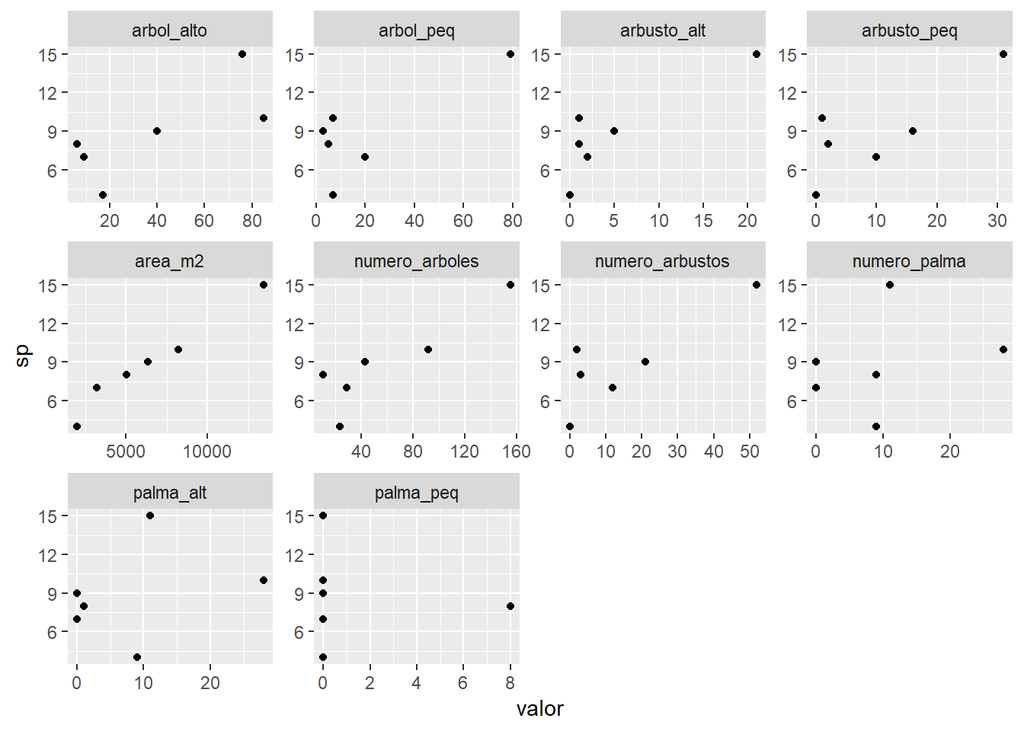

```r
# Luego se realiza un grafio, en cual indica el numero de especies entre el las diferentes variables, como arbol alto, entre  los  otros

modelo_final %>% select(-Parque) %>% select(-ID) %>%
  gather(key = "variable", value = "valor", -sp) %>%
  ggplot(aes(x = valor, y = sp)) +
  geom_point() +
  facet_wrap(~ variable, scales = "free")
```